# Analysis Of Peronal Productive Time

Alex Hacicu

2022-12-11

# Introduction

Welcome to my data analysis project on tracking my time spent on learning data analysis tasks! I have always been interested in understanding how I spend my time and how I can use that information to improve my productivity and efficiency.

I enrolled in the “Google Data Analyst Certificate” on Coursera to gain a deeper understanding of data analysis concepts and techniques. To track my time spent on the course, I used a stopwatch through the lessons and assignments. In addition to my time spent on the Coursera course, I also tracked the time I spent learning specific data analysis skills outside of the course. This included working on skills such as SQL, R, Excel, and Databases

By collecting data on the duration of specific tasks related to learning data analysis, I hope to gain insights into my learning process and identify areas where I can make adjustments to better utilize my time. Throughout this project, I will be analyzing the data I have collected and presenting my findings in a clear and concise manner. I am excited to share my findings with you and hope that you will find them as interesting and informative as I do.

For this project I used the programming language R to analyze data and create graphs. By using R to analyze and visualize my data, I was able to gain insights into my learning process and identify patterns and trends in my data.

# Import and Explore data

```r
# Load Libraries
library(tidyverse)
library(lubridate)
```

### Import data

```r
df <- read.csv("/Users/alexh/Downloads/Analyze_2022fin.csv")
```

### Explore data

```r
head(df)
```

```
##       Data                        Task Minute.per.Task Week.of.Year Day.of.Week
## 1 3-Jan-22 Google Data Analitycs Cours              80            1           1
## 2 3-Jan-22                        Work             450            1           1
## 3 4-Jan-22 Google Data Analitycs Cours              60            1           2
## 4 4-Jan-22                        Work             570            1           2
## 5 5-Jan-22 Google Data Analitycs Cours              60            1           3
## 6 5-Jan-22                        Work             570            1           3
```

```r
colnames(df)
```

```
## [1] "Data"            "Task"            "Minute.per.Task" "Week.of.Year"
## [5] "Day.of.Week"
```

```r
str(df)
```

```
## 'data.frame':    578 obs. of  5 variables:
##  $ Data           : chr  "3-Jan-22" "3-Jan-22" "4-Jan-22" "4-Jan-22" ...
##  $ Task           : chr  "Google Data Analitycs Cours" "Work" "Google Data Analitycs Cours" "Work" ...
##  $ Minute.per.Task: int  80 450 60 570 60 570 360 50 60 45 ...
##  $ Week.of.Year   : int  1 1 1 1 1 1 1 1 1 1 ...
##  $ Day.of.Week    : int  1 1 2 2 3 3 4 4 4 5 ...
```

# Clean and Prepare Data

```r
## fix inconsistent data and formats
# rename columns names in a more practical and consistent way
df <- df %>%
  drop_na() %>%                       #drop NA values if any
  rename(minutes = "Minute.per.Task",
         activity = Task,
         date = Data)                 #fix typo

# convert date column into date format
df$date <-  dmy(df$date)

# add new columns for day, week and month to the data frame, based on existing date column

df <- df %>%
  mutate(day = weekdays(date),
        week = isoweek(date),
        month = months(date))

# remove old columns to avoid duplication
data.frame(colnames(df))               # show index number for each column
```

```
##   colnames.df.
## 1         date
## 2     activity
## 3      minutes
## 4 Week.of.Year
## 5  Day.of.Week
## 6          day
## 7         week
## 8        month
```

```r
df <- df[, -c(4,5)]                    # remove old columns for week and day
colnames(df)                           # check columns name
```

```
## [1] "date"     "activity" "minutes"  "day"      "week"     "month"
```

```r
str(df)                                # display the structure of df
```

```
## 'data.frame':    578 obs. of  6 variables:
##  $ date    : Date, format: "2022-01-03" "2022-01-03" ...
##  $ activity: chr  "Google Data Analitycs Cours" "Work" "Google Data Analitycs Cours" "Work" ...
##  $ minutes : int  80 450 60 570 60 570 360 50 60 45 ...
##  $ day     : chr  "Monday" "Monday" "Tuesday" "Tuesday" ...
##  $ week    : num  1 1 1 1 1 1 1 1 1 1 ...
##  $ month   : chr  "January" "January" "January" "January" ...
```

```r
# fix inconsistent in Activity column
unique(df$activity)                   #show unique activities names
```

```
## [1] "Google Data Analitycs Cours" "Work"
## [3] "Excel"                       "SQL"
## [5] "Statistics"                  "Databases"
## [7] "R"
```

```r
# rename activity * DA = Data Analytics
df$activity[df$activity == 'Google Data Analitycs Cours'] <- 'Google DA Certificat'

# check incosisntens in minutes column
min(df$minutes)                        #show min value
```

```
## [1] 0
```

```r
max(df$minutes)                        #show max value
```

```
## [1] 570
```

```r
head(df[order(df$minutes),])           #order values small to large
```

```
##           date             activity minutes      day week     month
## 198 2022-04-15                 Work       0   Friday   15     April
## 204 2022-04-18                 Work       0   Monday   16     April
## 117 2022-02-24            Databases      10 Thursday    8  February
## 367 2022-07-31                    R      10   Sunday   30      July
## 418 2022-09-10                    R      10 Saturday   36 September
## 178 2022-04-05 Google DA Certificat      12  Tuesday   14     April
```

```r
df<-df[!(df$minutes==0), ]             #remove 0 values
```

```r
## Separate work from data Data Analytics activities and create two separata data frames
# create a vector with all the Data Analytics activities
data <- c("Google DA Certificat", "SQL",
          "Excel","R","Statistics", "Databases")
# data analitycs activities
data_df <- df %>%
  drop_na() %>%                      #remove NA values
  filter(activity %in% data)

# work data frame
work_df <- df[(df$activity %in% "Work"),]

#check all the df
unique(data_df$activity)
```

```
## [1] "Google DA Certificat" "Excel"                "SQL"
## [4] "Statistics"           "Databases"            "R"
```

```r
unique(work_df$activity)
```

```
## [1] "Work"
```

```r
head(data_df)
```

```
##         date             activity minutes       day week   month
## 1 2022-01-03 Google DA Certificat      80    Monday    1 January
## 2 2022-01-04 Google DA Certificat      60   Tuesday    1 January
## 3 2022-01-05 Google DA Certificat      60 Wednesday    1 January
## 4 2022-01-06                Excel      50  Thursday    1 January
## 5 2022-01-06 Google DA Certificat      60  Thursday    1 January
## 6 2022-01-07                Excel      45    Friday    1 January
```

```r
#set levels for months and day columns

data_df$day <- ordered(data_df$day,
                             levels=c("Monday", "Tuesday", "Wednesday",
                                      "Thursday", "Friday", "Saturday", "Sunday"))

data_df$month <- ordered(data_df$month,
                         levels=month.name, labels=month.abb)

#aggregate data for month, week and day
setNames(aggregate(data_df$minutes ~  data_df$month , FUN = sum),
                       c("month", "minutes"))
```

```
##    month minutes
## 1    Jan    2499
## 2    Feb    2310
## 3    Mar    2259
## 4    Apr    2100
## 5    May    2045
## 6    Jun     863
## 7    Jul    2184
## 8    Aug     512
## 9    Sep     398
## 10   Oct    1521
## 11   Nov    3151
## 12   Dec    1918
```

```r
head(setNames(aggregate(data_df$minutes ~  data_df$week , FUN = sum),
                       c("week", "minutes")))
```

```
##   week minutes
## 1    1     645
## 2    2     460
## 3    3     505
## 4    4     769
## 5    5     746
## 6    6     521
```

```r
setNames(aggregate(data_df$minutes ~  data_df$day , FUN = sum),
                       c("day", "minutes"))
```

```
##         day minutes
## 1    Monday    3383
## 2   Tuesday    2773
## 3 Wednesday    3389
## 4  Thursday    2831
## 5    Friday    3973
## 6  Saturday    1866
## 7    Sunday    3545
```

# Vizualization

To create visual graphs using ggplot in R, I used the ggplot() function to initialize the plot, then used the aes() function to specify the variables for the x and y axes. I grouped the data by month and week using the group_by() function from the dplyr package and summarized the data by minutes using the summarize() function. I created a bar chart with the geom_bar() function and a line chart with the geom_line() function. I labeled the plot with ggtitle(), xlab() and ylab() to make it more informative.

I also used theme_bw() to change the overall theme of the chart to black and white, making it more clear and easy to read. Additionally, I adjusted the point size and opacity of the chart using the alpha argument. This helped to make the chart more visually appealing and to make any patterns or trends more clear.

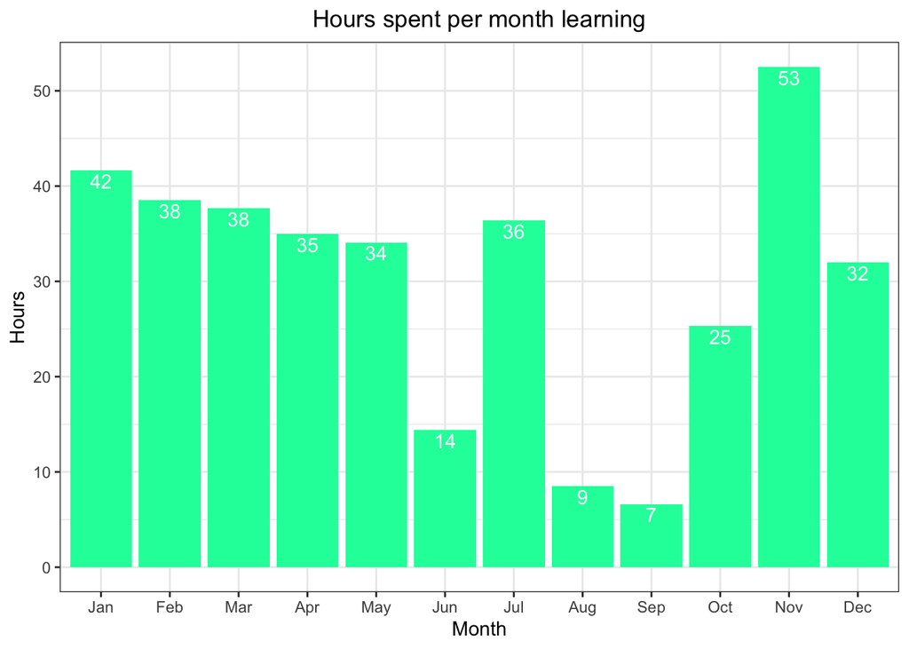

```r
data_df %>%
  group_by(month) %>%
  summarise(sum = sum(minutes) / 60) %>%
  ggplot(aes(x = month, y = sum)) +
  theme_bw()+
  geom_bar(stat ='identity',fill = "#03fca9") +
  labs(title = "Hours spent per month learning")+
  xlab("Month") +
  ylab("Hours")+
  theme(plot.title=element_text(hjust=0.5))+
  geom_text(aes(label = round(sum)),
              vjust = 1.25,
              color = 'white')
```

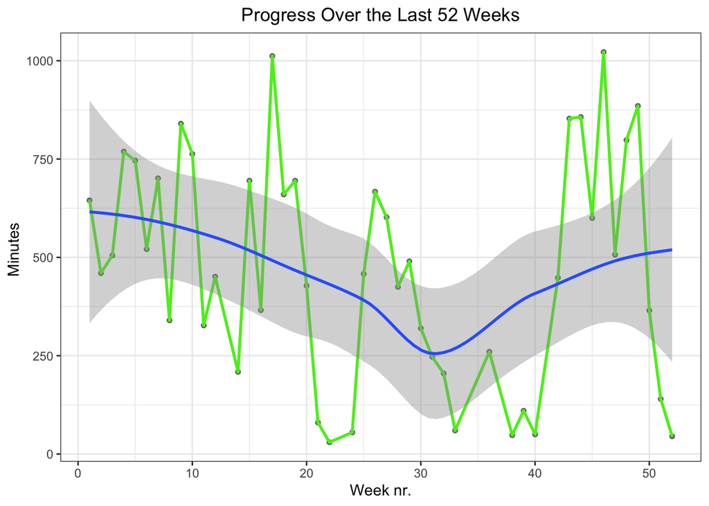

```r
data_df %>%
  group_by(week) %>%
  summarise(sum = sum(minutes)) %>%
  ggplot(aes(week, sum)) +
  geom_point(size = 1.3, alpha = 0.5) +
  geom_line(size = 1, colour = "#5aeb21") +
  geom_smooth() +
  theme_bw()+
  labs(title = "Progress Over the Last 52 Weeks")+
  xlab("Week nr.") +
  ylab("Minutes ")+
  theme(plot.title=element_text(hjust=0.5))
```

# Pie Chart

The pie chart I created using ggplot shows the percentage of time I spent on different skills related to learning data analysis, such as SQL, R, Excel, Database and Statistics, as well as the time spent on Coursera.org. Each slice of the pie represents a different skill and the size of each slice corresponds to the percentage of time I spent on that skill. The pie chart provides a clear visual representation of how much time I spent on each skill, making it easy to compare and understand the distribution of my time among the different skills.

```r
#create a tabel with all data analisys activities
pie_tabel <-  setNames(aggregate(data_df$minutes ~ data_df$activity, FUN = sum),
                       c("activity", "minutes"))

#create precent col
total_data_time <- sum(data_df$minutes)



#calculate procent for every Data Analytics activity and sotre it in a variable
for (i in length(pie_tabel$activity)) {
  act_vector <- round(pie_tabel$minutes / total_data_time * 100, 0)
}
```

```r
# create new colom and add the precent values
pie_tabel$precent <- act_vector
head(pie_tabel)
```

```
##               activity minutes precent
## 1            Databases    3248      15
## 2                Excel    2117      10
## 3 Google DA Certificat    5305      24
## 4                    R    6421      30
## 5                  SQL    3536      16
## 6           Statistics    1133       5
```

```r
#create vecotrs for activity and procent
activity <- pie_tabel$activity
precent <- pie_tabel$precent

#reorder the vecotr Activity in asceding order of precent
activity <- activity[order(precent)]; precent <- sort(precent)
#convert vector activity as a factor
activity.factor <- factor(activity, levels = as.character(activity))
```

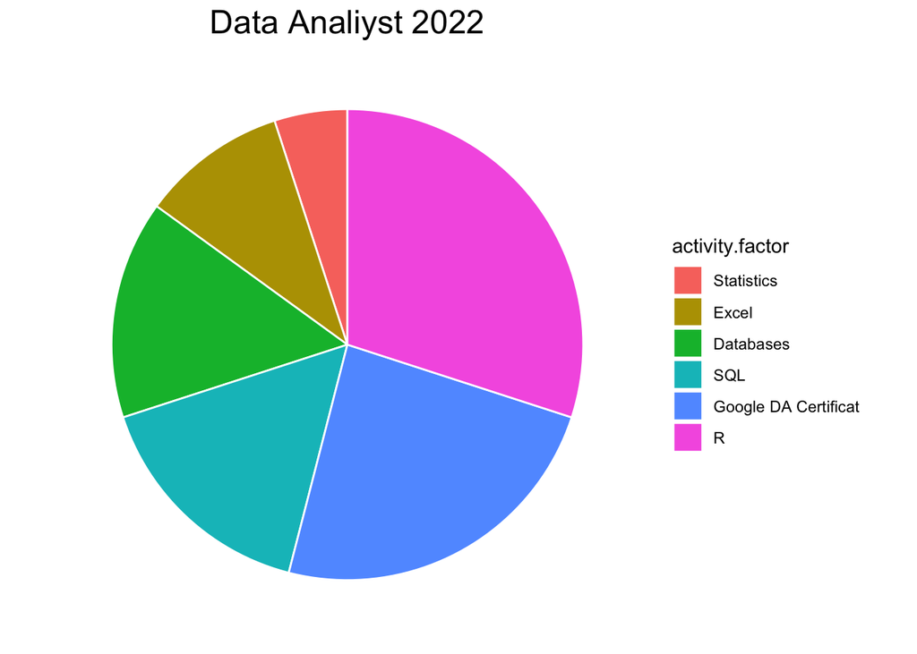

```r
pie <- ggplot() + theme_bw() +
  geom_bar(aes(x ="", y = precent, fill = activity.factor),
           stat = "identity", color = "white") +
  coord_polar("y", start = 0) +
  ggtitle("Data Analiyst 2022") + # add title
  theme(plot.title = element_text(hjust = 0.5, size = 18),    #center title and set title size
        axis.title = element_blank(),                         #remove axis titles
        axis.text = element_blank(),                          #remove numbers
        axis.ticks = element_blank(),                         #remove tick on the Y-axis
        panel.grid = element_blank(),                         #remove the circular grid
        panel.border = element_blank())                       #remove the square border

print(pie)
```

# Add aestetics to the pie chart

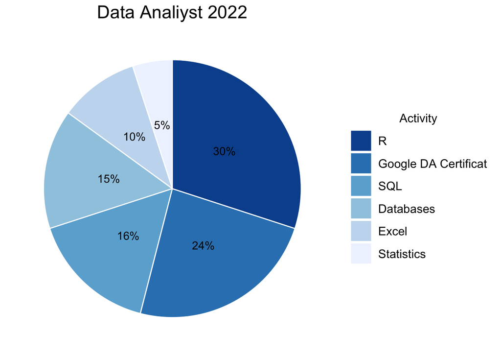

```r
ypos <- cumsum(precent) -0.5 * precent                        #desemnate the center
ypos <- 100 - ypos                                            #move in clockwise


#order labels in desiding order
pie + guides(fill = guide_legend(reverse = TRUE)) +
  scale_fill_brewer(palette = "Blues", name = "Activity") +
  theme(legend.text = element_text(size = 12),                      #increase font of Activity names
        legend.title = element_text(hjust = 0.5, size = 12),        #center legend  title and increase font title
        legend.key.size = unit(0.8, "cm")                           #set legend size of legend keys
        )+
  geom_text(aes(x = "", y = ypos, label = paste0(precent, "%")), size = 4)
```

# Records

In this chapter, I present a comprehensive record of my achievements for the year 2022. Through the use of advanced data analysis techniques and functions, I have compiled a detailed table that serves as a record of my performance throughout the year.

This recordbook serves as a valuable resource for understanding my successes and areas for improvement, and the insights I have gained through this analysis will be used to drive future growth and development.

```r
### Create a table with records

## Create a data frame with
#generate a sequence of dates from first day to last day of the year
date <- seq(as.Date("2022-01-03"),as.Date("2022-12-31"),1)

#convert the date vector into a data frame
all_days <- data.frame(date)


#add new columns to the data frame to match data_df
all_days <- all_days %>%
  mutate(activity = "No activity",                                              #add only one activity(No activity) for all dates
         minutes = as.integer(0),                                               #set minutes(0) for all dates
         day = weekdays(date),
         week = isoweek(date),
         month = months(date))

#check column names for two data frames
colnames(all_days)
```

```
## [1] "date"     "activity" "minutes"  "day"      "week"     "month"
```

```r
colnames(data_df)
```

```
## [1] "date"     "activity" "minutes"  "day"      "week"     "month"
```

```r
#combine to main df with the new one
one_year <- rbind(data_df, all_days)


#aggregate
days <- setNames(aggregate(one_year$minutes ~ one_year$date + one_year$week , FUN = sum),
                    c("date", "week", "minutes"))

#add a column to count consecutive days with activities
days$consec_days <- with(days, ave(minutes, data.table::rleid(minutes > 0),
                                   FUN = function(x) ifelse(x > 0, seq_along(x), 0L)))
#view head of df
head(days)
```

```
##         date week minutes consec_days
## 1 2022-01-03    1      80           1
## 2 2022-01-04    1      60           2
## 3 2022-01-05    1      60           3
## 4 2022-01-06    1     110           4
## 5 2022-01-07    1     105           5
## 6 2022-01-08    1      90           6
```

```r
# store values for record tabel
nr_days <- n_distinct(all_days$date)
nr_act <- nrow(data_df)
days_with_act <- nrow(days[days$minutes > 0,])
days_with_no_act <- nrow(days[days$minutes == 0,])
total_minutes <- sum(days$minutes)
total_hours <- round(sum(days$minutes) /60)
avrage_min_day <- round(mean(days$minutes))
consec_days_act <- max(days$consec_days)


# create vectors for names and cound
records <- c("Total days","Numer of Activities","Days with Activties",
                   "Days without activities", "Total minutes", "Total hours","Minutes per Day", "Consectuvie days with activity")
count <- c(nr_days,nr_act,days_with_act,days_with_no_act,
           total_minutes,total_hours,avrage_min_day, consec_days_act)

# create data frame form the two vectors
rec <- data.frame(records, count)

# 2022 record tabel
rec
```

```
##                          records count
## 1                     Total days   363
## 2            Numer of Activities   306
## 3            Days with Activties   237
## 4        Days without activities   126
## 5                  Total minutes 21760
## 6                    Total hours   363
## 7                Minutes per Day    60
## 8 Consectuvie days with activity    41
```

# Conclusion

One of the key takeaways from this project is the ability to translate my everyday work into clear and meaningful visualizations using data analysis. Through the use of advanced data analysis techniques and functions, I have been able to create a comprehensive record of my achievements for the year 2022. The table provides a clear and organized summary of my key activities, events and results for the year.

Furthermore, the insights I have gained through this analysis have helped me to understand my strengths and areas for improvement, and has allowed me to drive future growth and development in my work. This project has shown me the power of data analysis in providing a clear picture of performance, and the importance of consistency in mastering this skill. I believe that this project has provided a valuable learning experience and a foundation for continued growth and development as a data analyst.